# Access Notebooks from Databricks

### Save your Access token to Databricks

1. In Databricks click **Settings** in the bottom left of the screen.
2. Click **User Settings**
3. Go to the **Git integration** tab
4. In the Git provider drop-down, select **GitHub**
5. Enter your GitHub user name or email
6. Paste the access token into the **Token** Field
7. Click **Save**

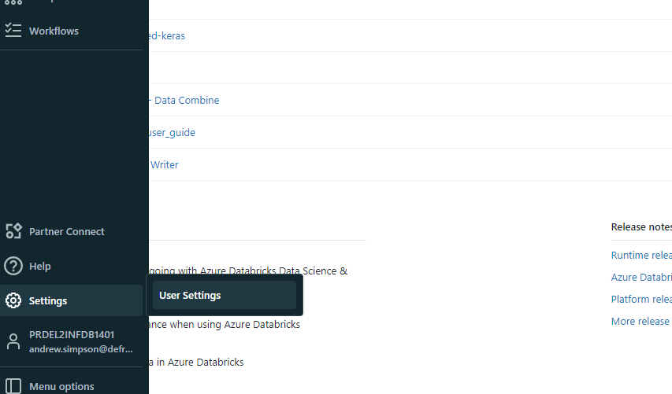

### Add Repo

[figure not shown]

The Repo will now be added, you can click on it to navigate to the different notebooks available. These can be cloned into your workspace where you can run them at your leisure.